# Logistic Regression - Week 13, Day 2

Author

Hector Gavilanes

```r
# clear environment
rm(list = ls())
# load data
data <- as_tibble(gsheet2tbl("https://docs.google.com/spreadsheets/d/1TrJ6jZ3hP6gQk6FvqbMrFUysEUEqle7XfuLnAkZsHYI/edit"))
```

**1. Challenge! Research “good” values of the metrics we discussed in lecture. How can we determine how well the model is performing using these metrics?** There are different metrics to assess the quality of a model.

- Accuracy: The percentage of all observations that are correctly classified by the model.
- Sensitivity: The true positive rate; the probability of a positive test, conditioned on truly being positive.
- Specificity: The true negative rate; the probability of a negative test, conditioned on truly being negative.
- Total misclassification rate: The percentage of total incorrect classifications made by the model. The lower the value, the better.

There is no universal threshold to determine a “good” model. A baseline model which includes every observation in a dataset to belong to the most common class. A model with higher metrics than the baseline can be consider useful. The greater the difference in metrics, the better.

**2. Recall question 1 from the last activity.**

**2a. Restate the model from 1a here.**

## The Baseline model

```r
base_mod <- glm(data$Survived ~ data$Age + data$SibSp + data$Parch + data$Pclass + data$Fare,
          family = binomial,
          na.action = na.exclude)
summary(base_mod)
```

```
Call:
glm(formula = data$Survived ~ data$Age + data$SibSp + data$Parch +
    data$Pclass + data$Fare, family = binomial, na.action = na.exclude)

Deviance Residuals:
    Min       1Q   Median       3Q      Max
-2.4155  -0.8355  -0.6207   0.9942   2.4047

Coefficients:
             Estimate Std. Error z value Pr(>|z|)
(Intercept)  3.401026   0.505176   6.732 1.67e-11 ***
data$Age    -0.044566   0.007210  -6.181 6.36e-10 ***
data$SibSp  -0.292273   0.106079  -2.755  0.00586 **
data$Parch   0.247881   0.109075   2.273  0.02305 *
data$Pclass -1.153008   0.145943  -7.900 2.78e-15 ***
data$Fare    0.003294   0.002537   1.299  0.19402
---
Signif. codes:  0 '***' 0.001 '**' 0.01 '*' 0.05 '.' 0.1 ' ' 1

(Dispersion parameter for binomial family taken to be 1)

    Null deviance: 964.52  on 713  degrees of freedom
Residual deviance: 815.18  on 708  degrees of freedom
  (177 observations deleted due to missingness)
AIC: 827.18

Number of Fisher Scoring iterations: 4
```

```r
# get coefficients
base_coeff <- coefficients(base_mod)
```

$$\ln \left( \frac{\hat{\pi}}{1-\hat{\pi}} \right) = 3.401 -0.045 \text{ Age} -0.292 \text{ Sibling \& Spouse} + 0.248 \text{ Parents \& Children} -1.153 \text{ Class} + 0.003 \text{ Fare}$$

- Age (p < 0.001), Siblings & Spouses (p = 0.006), Parents & Children (p = 0.023), and Passenger Class (p < 0.001) are significant predictors of survival.
- Fare (0.194) is not a significant predictor of survival.

**2b. Find the confusion matrix for this model.**

```r
# get predicted values
data <- data %>%
  mutate(p_hat = predict(base_mod, type = "response"))

# misclassification error
data <- data %>%
  mutate(Predicted = ifelse(p_hat > 0.5, 1, 0))

# get Confusion Matrix cross-table
CrossTable(data$Predicted, data$Survived,
           prop.r = FALSE,
           prop.c = FALSE,
           prop.t = FALSE,
           prop.chisq = FALSE)
```

```
   Cell Contents
|-------------------------|
|                       N |
|-------------------------|


Total Observations in Table:  714


               | data$Survived
data$Predicted |         0 |         1 | Row Total |
---------------|-----------|-----------|-----------|
             0 |       351 |       140 |       491 |
---------------|-----------|-----------|-----------|
             1 |        73 |       150 |       223 |
---------------|-----------|-----------|-----------|
  Column Total |       424 |       290 |       714 |
---------------|-----------|-----------|-----------|
```

```r
# convert to factor
Actual = factor(data$Survived)
Predicted = factor(data$Predicted)

# get confusion matrix function
confusionMatrix(Predicted, Actual, positive = "1")
```

```
Confusion Matrix and Statistics

          Reference
Prediction   0   1
         0 351 140
         1  73 150

               Accuracy : 0.7017
                 95% CI : (0.6666, 0.735)
    No Information Rate : 0.5938
    P-Value [Acc > NIR] : 1.460e-09

                  Kappa : 0.3581

 Mcnemar's Test P-Value : 6.119e-06

            Sensitivity : 0.5172
            Specificity : 0.8278
         Pos Pred Value : 0.6726
         Neg Pred Value : 0.7149
             Prevalence : 0.4062
         Detection Rate : 0.2101
   Detection Prevalence : 0.3123
      Balanced Accuracy : 0.6725

       'Positive' Class : 1
```

**2c. Find the sensitivity of the model.**

```r
tp = 150
tn = 351
fn = 140
fp = 73

# get sensitivity (recall)
sensitivity = tp / (tp + fn)
round(sensitivity, 3)
```

```
[1] 0.517
```

```r
# get miscalculation error
misClassError(data$Survived, data$Predicted)
```

```
[1] 0.2391
```

```r
1 - 0.2391
```

```
[1] 0.7609
```

**2d. Find the specificity of the model.**

```r
# get specificity
specificity = tn / (tn + fp)
round(specificity, 3)
```

```
[1] 0.828
```

**2e. Find the positive predictive value of the model.**

```r
# get positive predictive value (Precision)
pos_pred_value = tp / (tp + fp)
round(pos_pred_value, 3)
```

```
[1] 0.673
```

**2f. Find the negative predictive value of the model.**

```r
# get negative predictive value
neg_pred_value = tn / (tn + fn)
round(neg_pred_value, 3)
```

```
[1] 0.715
```

**2g. Find the false discovery rate of the model.**

```r
# get false discovery rate
false_discovery_rate = fp / (fp + tp)
round(false_discovery_rate, 3)
```

```
[1] 0.327
```

**3. Compare and contrasts the results from the models constructed in lecture and the last activity. Which model performs better, based on your answer in question 1?**

- The model from Q2 can be considered as the baseline model because it has the most common variables of the dataset.
- The model shown in lecture had less variables; however, the model’s metrics are very similar to the baseline.
- For both models, the Fare variable is not a significant predictor of survival.
- Perhaps, it is possible to obtain a better model without the Fare variable.

## Conclusion

```r
# drop Cabin, Passenger-ID, Name, Ticket columns
clean_data <- subset(data,select=c(2,3,6,7,8,10))

# replace missing values with mean for Age
clean_data$Age[is.na(clean_data$Age)] <- mean(clean_data$Age,na.rm=T)

# baseline model
m2 <- glm(clean_data$Survived ~ clean_data$Age + clean_data$SibSp + clean_data$Parch + clean_data$Pclass + clean_data$Fare,
          family = binomial,
          na.action = na.exclude)

# lecture model
m3 <- glm(clean_data$Survived ~ clean_data$Age + clean_data$Pclass + clean_data$Fare,
          family = binomial,
          na.action = na.exclude)
# models comparison
anova(object = m2, m3,
      test = "Chisq")
```

```
Analysis of Deviance Table

Model 1: clean_data$Survived ~ clean_data$Age + clean_data$SibSp + clean_data$Parch +
    clean_data$Pclass + clean_data$Fare
Model 2: clean_data$Survived ~ clean_data$Age + clean_data$Pclass + clean_data$Fare
  Resid. Df Resid. Dev Df Deviance Pr(>Chi)
1       885     1033.2
2       887     1042.8 -2  -9.6047  0.00821 **
---
Signif. codes:  0 '***' 0.001 '**' 0.01 '*' 0.05 '.' 0.1 ' ' 1
```

**4. Challenge! Construct a graph to support your answer in question 3.**

## Baseline Model Confusion Matrix

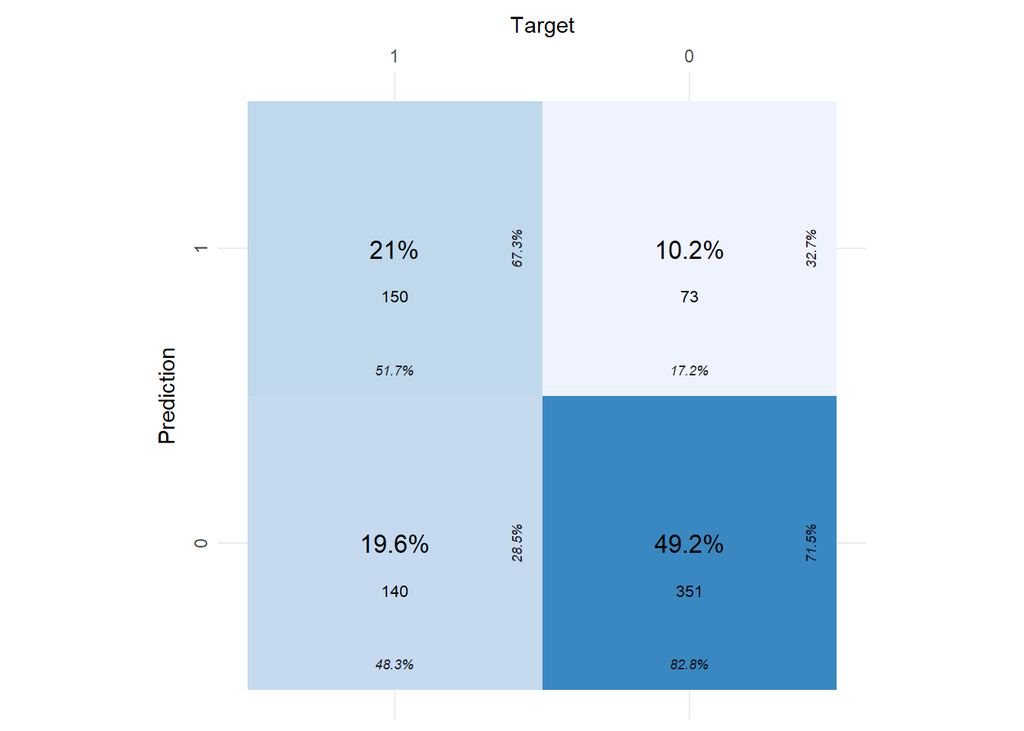

```r
# plot confusion matrix
base_matrix <- tibble("Predicted" = c(0, 0, 1, 1),
                      "Actual" =    c(0, 1, 0, 1),
                      "Counts" =    c(351, 140, 73, 150))

plot_confusion_matrix(base_matrix,
                      target_col = "Actual",
                      prediction_col = "Predicted",
                      counts_col = "Counts")
```

## Lecture Model Confusion Matrix

```r
# exclude missing values from the model
lecture_cf <- glm(data$Survived ~ data$Age + data$Pclass,
          family = binomial,
          na.action = na.exclude)

# get predicted values
lecture_data <- data %>%
  mutate(p_hat = predict(lecture_cf, type = "response"))

# misclassification error
lecture_data <- data %>%
  mutate(Predicted = ifelse(p_hat > 0.5, 1, 0))

# get Confusion Matrix cross-table
CrossTable(lecture_data$Predicted, lecture_data$Survived,
           prop.r = FALSE,
           prop.c = FALSE,
           prop.t = FALSE,
           prop.chisq = FALSE)
```

```
   Cell Contents
|-------------------------|
|                       N |
|-------------------------|


Total Observations in Table:  714


                       | lecture_data$Survived
lecture_data$Predicted |         0 |         1 | Row Total |
-----------------------|-----------|-----------|-----------|
                     0 |       351 |       140 |       491 |
-----------------------|-----------|-----------|-----------|
                     1 |        73 |       150 |       223 |
-----------------------|-----------|-----------|-----------|
          Column Total |       424 |       290 |       714 |
-----------------------|-----------|-----------|-----------|
```

```r
# convert to factor
Actual_lect = factor(lecture_data$Survived)
Predicted_lect = factor(lecture_data$Predicted)

# get confusion matrix function
confusionMatrix(Predicted_lect, Actual_lect, positive = "1")
```

```
Confusion Matrix and Statistics

          Reference
Prediction   0   1
         0 351 140
         1  73 150

               Accuracy : 0.7017
                 95% CI : (0.6666, 0.735)
    No Information Rate : 0.5938
    P-Value [Acc > NIR] : 1.460e-09

                  Kappa : 0.3581

 Mcnemar's Test P-Value : 6.119e-06

            Sensitivity : 0.5172
            Specificity : 0.8278
         Pos Pred Value : 0.6726
         Neg Pred Value : 0.7149
             Prevalence : 0.4062
         Detection Rate : 0.2101
   Detection Prevalence : 0.3123
      Balanced Accuracy : 0.6725

       'Positive' Class : 1
```

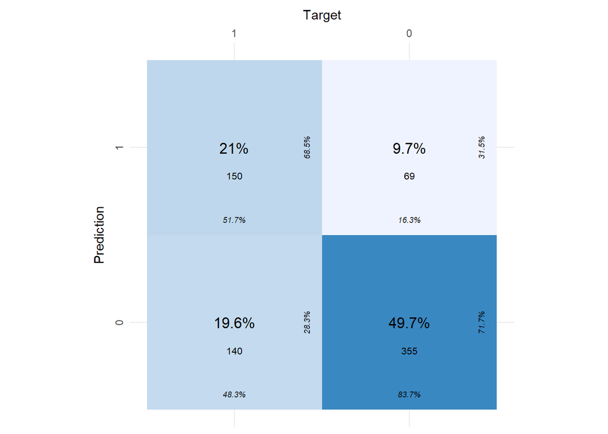

```r
# plot confusion matrix from Lecture
base_matrix <- tibble("Predicted" = c(0, 0, 1, 1),
                      "Actual" =    c(0, 1, 0, 1),
                      "Counts" =    c(355, 140, 69, 150))

plot_confusion_matrix(base_matrix,
                      target_col = "Actual",
                      prediction_col = "Predicted",
                      counts_col = "Counts")
```

### Baseline Model Plot for all Predictors

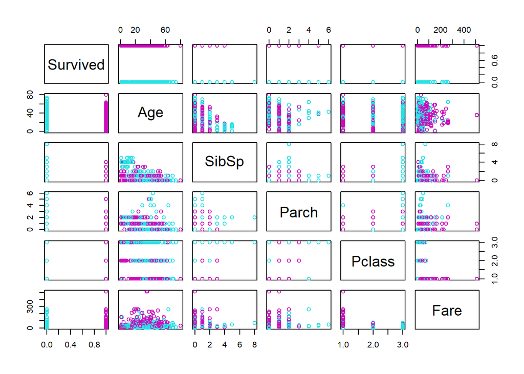

```r
pairs(
  x = data[, c("Survived", "Age", "SibSp", "Parch", "Pclass", "Fare")],
  col = data$Survived + 5)
```

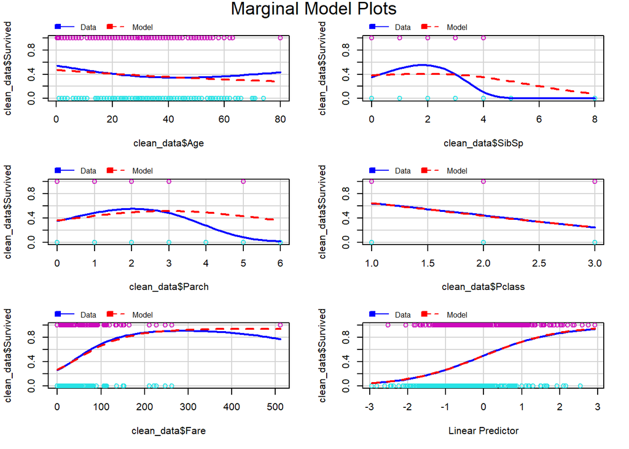

```r
library(car)
library(carData)

# baseline plot
car::mmps(model = m2,
          col = clean_data$Survived + 5)
```

## Lecture Model

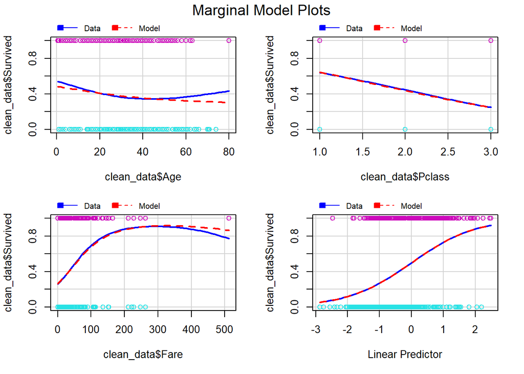

```r
# lecture plot
car::mmps(model = m3,
          col = clean_data$Survived + 5)
```

### Diagnostic Plots

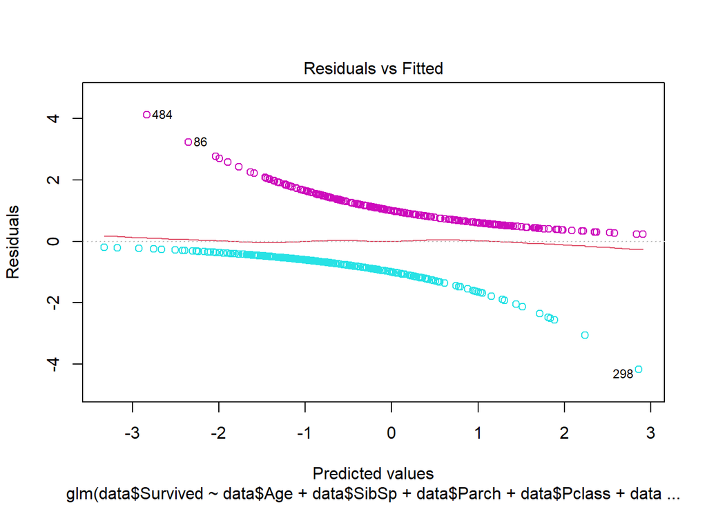

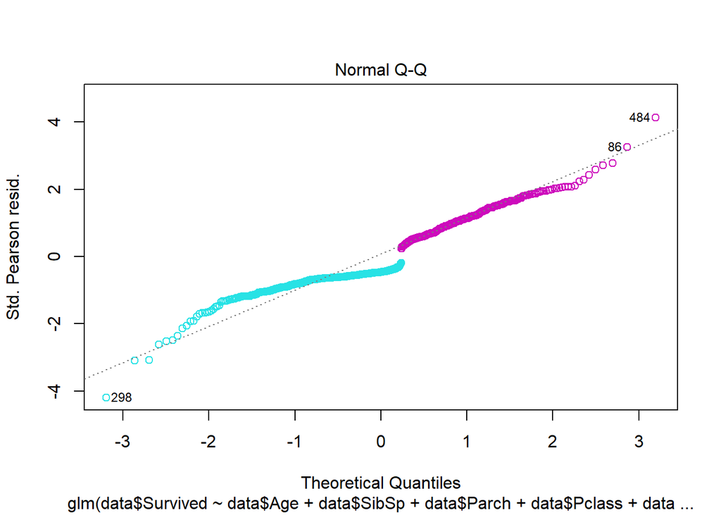

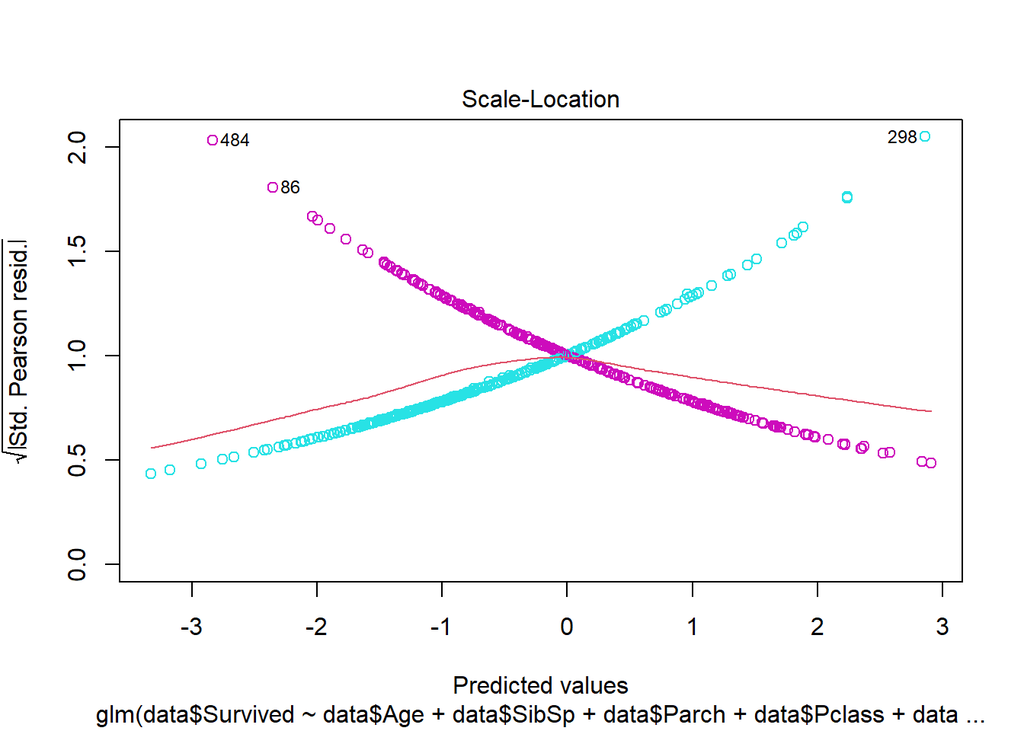

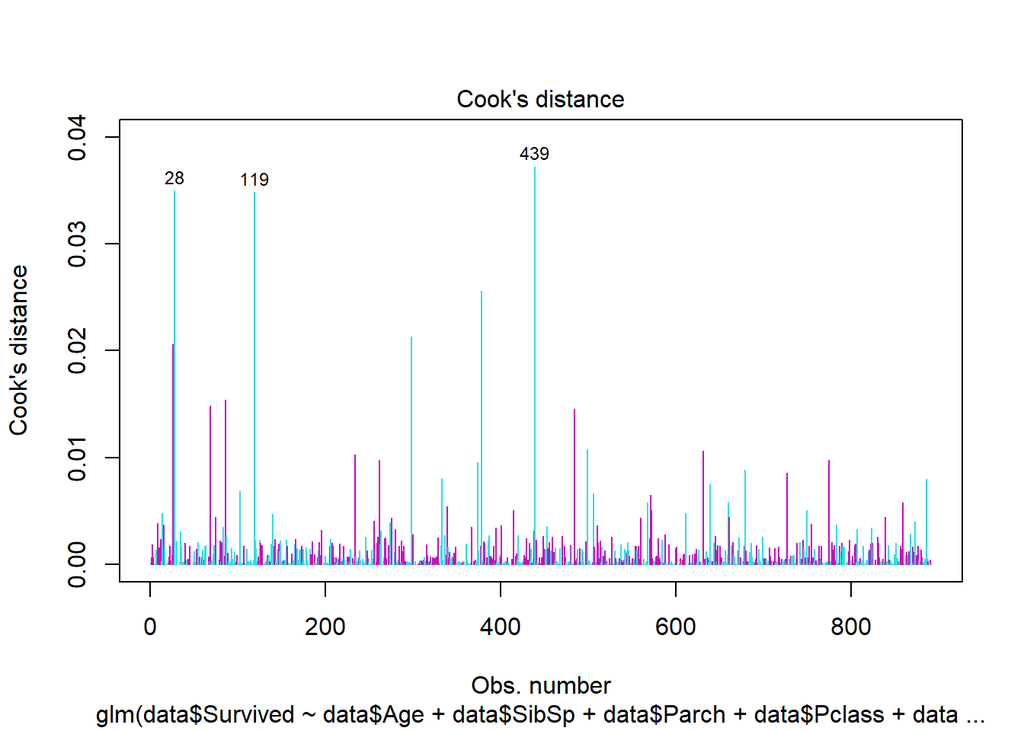

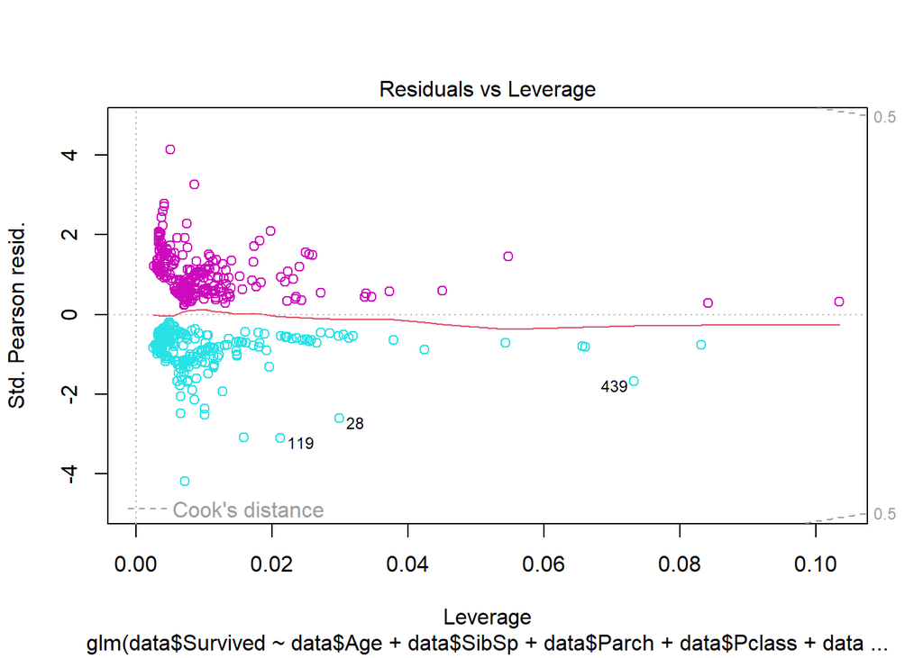

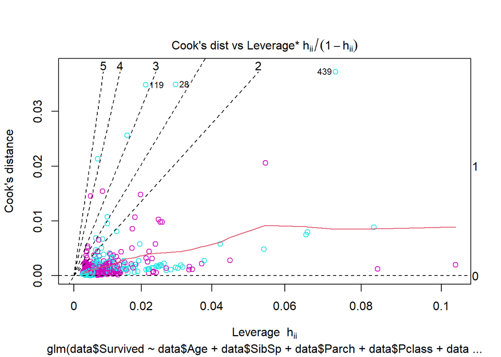

```r
plot(x = base_mod,
     which = 1:6,
     col = data$Survived + 5)
```